# Two-Tailed Tests

2025

## Introduction to two-tailed tests

- We have seen that **one-tailed tests** are used to determine if the mean of a sample is significantly greater than or less than a hypothesized value.
- **Two-tailed tests** are used to determine if the mean of a sample is significantly different from a hypothesized value.

## Imagine two universes

- **Null Universe**: The neuron is not stimulus-driven. The **Expected Value** of \(X\) is 10 spikes per second.
- **Alternative Universe**: The neuron is stimulus-driven but the drive can be excitatory or inhibitory.
- We want to know which universe we are in.
- We write this as:

\[ \begin{align*} H_0 &: \mu_X = 10 \\ H_1 &: \mu_X \neq 10 \end{align*} \]

## The null universe

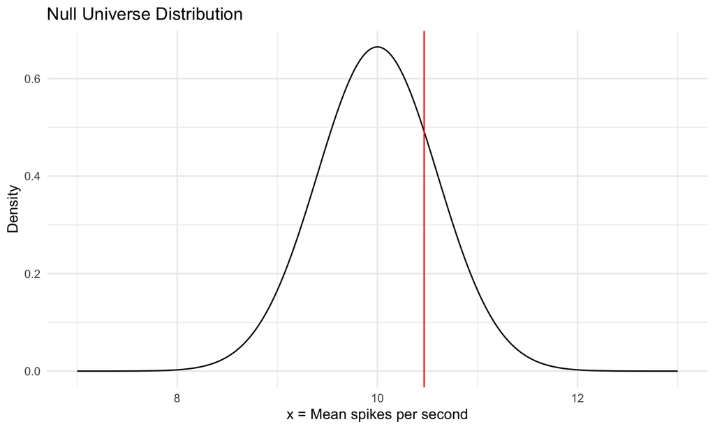

## Two-tailed p-value

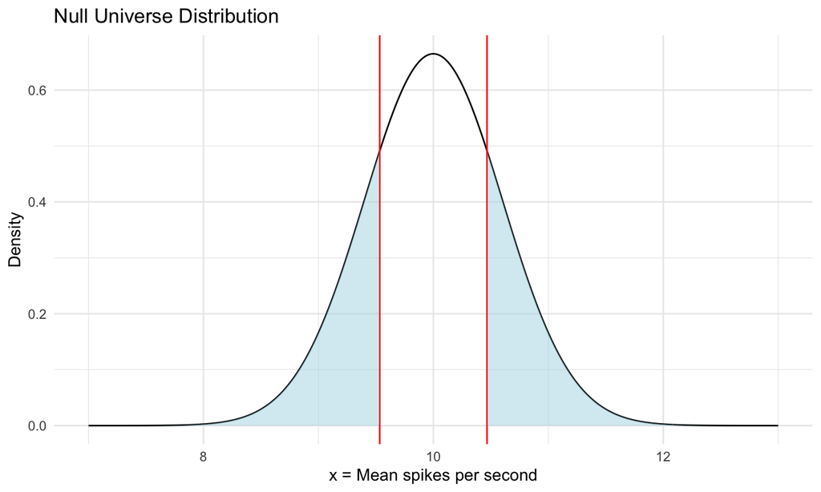

## Two-tailed recipe

- Everything proceeds the same as for a one-tailed test until you get to the p-value calculation.
- At that stage, you must mirror the observed test statistic value (e.g., the observed sample mean) across the center of the null distribution and compute the area under the curve in both tails.
1. Specify the null and alternative hypotheses (\(H_0\) and \(H_1\)) in terms of a population parameter \(\theta\).
2. Specify the type I error rate – denoted by the symbol \(\alpha\) – you are willing to tolerate.
3. Specify the sample statistic \(\widehat{\theta}\) that you will use to estimate the population parameter \(\theta\) in step 1 and state how it is distributed under the assumption that \(H_0\) is true.
4. Obtain a random sample and use it to compute the sample statistic from step 3. Call this value \(\widehat{\theta}_{\text{obs}}\).
5. If \(\widehat{\theta}_{\text{obs}}\) or a **more extreme outcome in either tail** is very unlikely to occur under the assumption that \(H_0\) is true, then reject \(H_0\). Otherwise, do not reject \(H_0\).

## Two-tailed example

- Suppose a neuron has a baseline firing rate of **10 spikes/sec**. After presenting a stimulus, we record a sample of **25 trials**, and observe:

  \[ \bar{X}_{\text{obs}} = 9.85 \text{ spikes/sec} \]
- We want to test:

  \[ \begin{align*} H_0 &: \mu_X = 10 \\ H_1 &: \mu_X \neq 10 \end{align*} \]
- Under \(H_0\), \(\bar{X} \sim \mathscr{N}(10, \frac{1^2}{25}) = \mathscr{N}(10, 0.04)\)

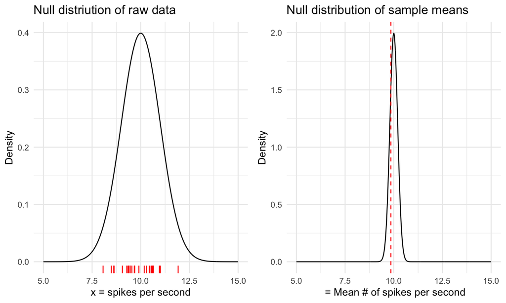

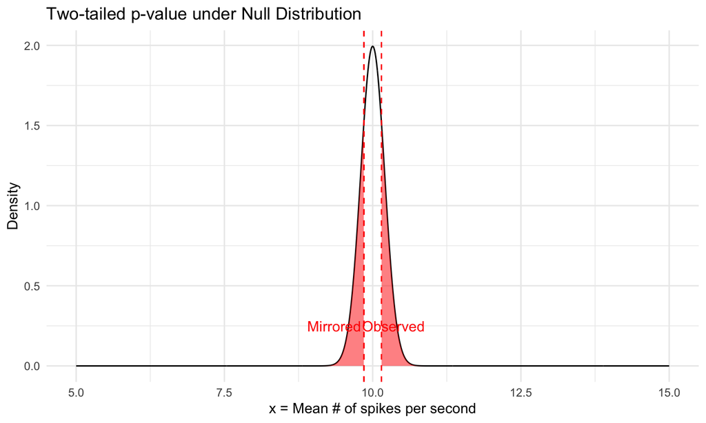